# Covariate Balance Tables and Plots: A Guide to the *cobalt* Package

### `bal.plot()`

The gold standard for covariate balance is multidimensional independence between treatment and covariates. Because this is hard to visualize and assess with the large numbers of covariates typical of causal effect analysis, univariate balance is typically assessed as a proxy. Most conditioning packages, as well as *cobalt*, will provide numerical summaries of balance, typically by comparing moments between the treated and control groups. But even univariate balance is more complicated than simple numerical summaries can address; examining distributional balance is a more thorough method to assess balance between groups. Although there are statistics such as the Kolmogorov-Smirnov statistic and the overlapping coefficient complement that attempt to summarize distributional balance beyond the first few moments (Austin and Stuart 2015; Ali et al. 2015), complimenting statistics with a visual examination of the distributional densities can be an effective way of assessing distributional similarity between the groups (Ho et al. 2007).

`bal.plot()` allows users to do so by displaying density plots, histograms, empirical CDF plots, bar graphs, and scatterplots so that users can visually assess independence between treatment and covariates before and after conditioning. Below is an example of the use of `bal.plot()` after using propensity score weighting for the ATT using the output from *WeightIt* generated above.:

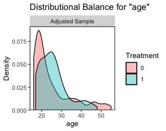

```r
bal.plot(W.out, var.name = "age")
```

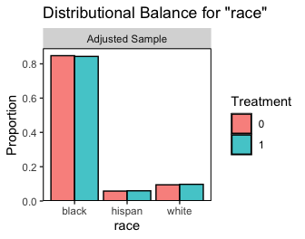

```r
bal.plot(W.out, var.name = "race")
```

The first argument (or set of arguments) is the sufficient set of arguments for a simple call to `bal.tab()`, defining the data object (e.g., the output of a conditioning function), the treatment indicators, and the weights or subclasses. See above for examples. The next argument is the name of the covariate for which distributional balance is to be assessed. If subclassification is used (i.e., if subclasses are present in the input data object or arguments), an additional argument `which.sub` can be specified, with a number corresponding to the subclass number for which balance is to be assessed on the specified covariate; if it is not specified, plots for all subclasses will be displayed.

The user can also specify whether distributional balance is to be shown before or after adjusting or both by using the argument to `which`. If `which = "unadjusted"`, balance will be displayed for the unadjusted sample only. If `which = "both"`, balance will be displayed for both the unadjusted sample and the adjusted sample. The default is to display balance for the adjusted sample.

The output of `bal.plot()` is a density plot, histogram, or empirical CDF plot for the two groups on the given covariate, depending on the argument to `type`. For categorical or binary variables, a bar graph is displayed instead. When multi-category categorical variables are given, bars will be created for each level, unlike in `bal.tab()`, which splits the variable into several binary variables. The degree to which the densities for the two groups overlap is a good measure of group balance on the given covariate; significant differences in shape can be indicative of poor balance, even when the mean differences and variance ratios are well within thresholds. Strong distributional similarity is especially important for variables strongly related to the outcome of interest.

Distributional balance can also be assessed on the distance measure, and this can form an alternative to other common support checks, like *MatchIt*’s `plot(..., type = "hist")` or *twang*’s `plot(..., plots = "boxplot")`. To examine the distributions of the distance measure, the input to `var.name` must be the name of the distance variable. If the data input object doesn’t already contain the distance measure (e.g., if not using one of the conditioning packages), the distance measure must be manually added as an input to `bal.plot()` through `distance`, in addition to being called through `var.name`.

Below is an example using `bal.plot()` to display the distributions of propensity scores before and after weighting adjustment:

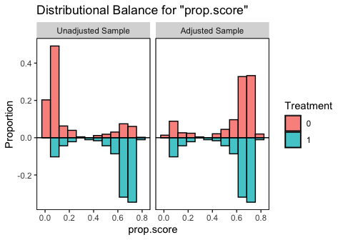

```r
#Before and after weighting; which = "both"
bal.plot(W.out, var.name = "prop.score",
         which = "both",
         type = "histogram",
         mirror = TRUE)
```

Setting `type = "histogram"` produces a histogram rather than a density plot, and setting `mirror = TRUE` creates a mirrored plot rather than overlapping histograms. Mirroring only works with binary treatments.

It is generally not a useful assessment of balance to examine the overlap of the distance measure distributions after adjustment, as most conditioning methods will yield good distributional overlap on the distance measure whether or not balance is achieved on the covariates (Stuart et al. 2013). However, it may be useful to see the new range of the distance measure if calipers or common support pruning are used.

The output plot is made using *ggplot2*, which means that users familiar with *ggplot2* can adjust the plot with *ggplot2* commands.

When the treatment variable is continuous, users can use `bal.plot()` to examine and assess dependence between the covariate and treatment. The arguments given to `bal.plot()` are the same as in the binary treatment case, but the resulting plots are different. If the covariate is continuous, a scatterplot between the covariate and the treatment variable will be displayed, along with a linear fit line, a Loess curve, and a reference line indicating linear independence. Used together, these lines can help diagnose departures from independence beyond the simple correlation coefficient. Proximity of the fit lines to the reference line is suggestive of independence between the covariate and treatment variable. If the covariate is categorical (including binary), density plots of the treatment variable for each category will be displayed. Densities that overlap completely are indicative of independence between the covariate and treatment. See the section “Using cobalt with continuous treatments” for more details and an example.

### `love.plot()`

The Love plot is a summary plot of covariate balance before and after conditioning popularized by Dr. Thomas E. Love. In a visually appealing and clear way, balance can be presented to demonstrate to readers that balance has been met within a threshold, and that balance has improved after conditioning [which is not always the case; cf. King and Nielsen (2019)]. `love.plot()` does just this, providing the user with several options to customize their plot for presentation. Below is an example of its use:

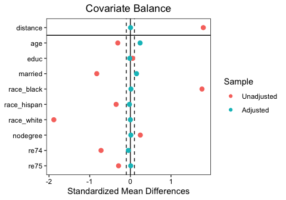

```r
data("lalonde", package = "cobalt")

# Nearest neighbor 1:1 matching with replacement
m.out <- MatchIt::matchit(treat ~ age + educ + married + race +
                              nodegree + re74 + re75,
                          data = lalonde,
                          method = "nearest",
                          replace = TRUE)

love.plot(m.out, binary = "std", thresholds = c(m = .1))
```

`love.plot()` takes as its arguments the same ones that would go into a call to `bal.tab()`. In addition, it can take as its first argument the output of a call to `bal.tab()`; this can be accomplished simply by inserting the `bal.tab()` call into the first argument or by saving the result of a call to `bal.tab()` to an object and inserting the object as the argument. There are several other arguments, all of which control display, that are described below.

The output is a plot with the balance statistic on the X-axis and the covariates output in `bal.tab()` on the Y-axis. Each point represents the balance statistic for that covariate, colored based on whether it is calculated before or after adjustment. The dotted lines represent the threshold set in the `threshold` argument; if most or all of the points after adjustment are within the threshold, that is good evidence that balance has been achieved.

The `thresholds` argument works similarly to how it does in `bal.tab()`; specifying it is optional, but doing so will provide an additional point of reference on which to evaluate the displayed balance measures.

If mean difference are requested, `love.plot()` will use the mean differences as they are calculated by `bal.tab()` and presented in the mean differences columns of the balance table. See the section on using `bal.tab()` to see what the default calculations are for these values. If `abs = TRUE` in `love.plot()`, the plot will display absolute mean differences, which can aid in display clarity since the magnitude is generally the more important aspect of the statistic.

The order of the covariates displayed can be adjusted using the argument to `var.order`. If left empty or `NULL`, the covariates will be listed in the order of the original dataset. If `"adjusted"`, covariates will be ordered by the requested balance statistic of the adjusted sample. If `"unadjusted"`, covariates will be ordered by the requested balance statistic of the unadjusted sample, which tends to be more visually appealing. Abbreviations are allowed. The distance variable(s), if any, will always be displayed at the top. They can be omitted by setting `drop.distance = TRUE`.

The plot uses the original variable names as they are given in the data set, which may not be the names desired for display in publication. By using the argument to `var.names`, users can specify their own variable names to be used instead. To specify new variable names with `var.names`, the user must enter an object containing the new variable names and, optionally, the old variable names to replace. For options of how to do so, see the help file for the display options with `?display-options`. Below is an example, creating a publication-ready plot with a few other arguments to customize output:

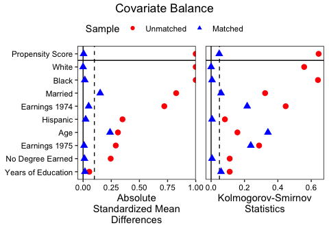

```r
v <- data.frame(old = c("age", "educ", "race_black", "race_hispan",
                        "race_white", "married", "nodegree", "re74", "re75", "distance"),
                new = c("Age", "Years of Education", "Black",
                        "Hispanic", "White", "Married", "No Degree Earned",
                        "Earnings 1974", "Earnings 1975", "Propensity Score"))

love.plot(m.out, stats = c("mean.diffs", "ks.statistics"),
          threshold = c(m = .1, ks = .05),
          binary = "std",
          abs = TRUE,
          var.order = "unadjusted",
          var.names = v,
          limits = c(0, 1),
          grid = FALSE,
          wrap = 20,
          sample.names = c("Unmatched", "Matched"),
          position = "top",
          shapes = c("circle", "triangle"),
          colors = c("red", "blue"))
```

This plot shows that balance was improved on almost all variables after adjustment, bringing all but two below the threshold of .1 for absolute mean differences.

A helper function, `var.names()` can be used to more easily create new variable names when many variables are present. See `?var.names` for details.

`var.names` can also be supplied to `bal.tab()` itself, in which case the names are used everywhere the resulting object is displayed—by `print()`, `format()`, `as.data.frame()`, and `love.plot()`—so a set of readable names need only be settled on once. Each of those still takes a `var.names` of its own, which adds to the one given to `bal.tab()` and replaces any entry it names. Only the displayed names change; the variables are still stored, and still selected, under their own names. See `?display-options`.

```r
b <- bal.tab(m.out, var.names = v)
b
```

```
## Balance Measures
##                        Type Diff.Adj
## Propensity Score   Distance   0.0044
## Age                 Contin.   0.2395
## Years of Education  Contin.  -0.0161
## Married              Binary   0.0595
## Black                Binary   0.0054
## Hispanic             Binary  -0.0054
## White                Binary   0.0000
## No Degree Earned     Binary   0.0054
## Earnings 1974       Contin.  -0.0493
## Earnings 1975       Contin.   0.0087
##
## Sample sizes
##                      Control Treated
## All                   429.       185
## Matched (ESS)          46.31     185
## Matched (Unweighted)   82.       185
## Unmatched             347.         0
```

Like the output of `bal.plot()`, the output of `love.plot()` is a *ggplot2* object, which means *ggplot2* users can modify the plot to some extent for presentation or publication. Several aspects of the appearance of the plot can be customized using the `love.plot()` syntax, including the size, shape, and color of the points, the title of the plot, whether to display grid lines, and whether to display lines connecting the points. See `?love.plot` for details. It may be challenging to make adjustments to these aspects using *ggplot2* syntax, so these arguments allow for some simple adjustments. See `vignette("love.plot")` for information on more of `love.plot()`’s features.

## Additional Features

### Using *cobalt* with continuous treatments

Although the most common use of propensity scores is in the context of binary treatments, it is also possible to use propensity scores with continuous treatment to estimate dose-response functions while controlling for background variables (Hirano and Imbens 2005). As in the binary case, the goal of propensity score adjustment in the continuous case is to arrive at a scenario in which, conditional on the propensity score, treatment is independent of background covariates. When this is true (and there are no unmeasured confounders), treatment is also independent of potential outcomes, thereby meeting the strong ignorability requirement for causal inference.

Bia and Mattei (2008) describe the use of the `gpscore` function in Stata, which appears to be effective for estimating and assessing dose-response functions for continuous treatments. In R, there are a few ways to estimate and condition on the propensity score in these contexts. It is possible, using the formulas described by Hirano and Imbens (2005), to generate the propensity scores manually and perform weighting, subclassification, or covariate adjustment on them. The *WeightIt* package supports continuous treatments with a variety of options, including the CBPS method described by Fong et al. (2018), GBM as described by Zhu et al. (2015), and entropy balancing as described by Vegetabile et al. (2021), among others.

In *cobalt*, users can assess and present balance for continuous treatments using `bal.tab()`, `bal.plot()`, and `love.plot()`, just as with binary treatments. The syntax is almost identical in both cases regardless of the type of treatment variable considered, but there are a few differences and specifics worth noting. The approach *cobalt* takes to assessing balance is to display correlations between each covariate and the treatment variable, which is the approach used in *CBPS* and described in Zhu et al. (2015) and Austin (2019), but not that described in Hirano and Imbens (2005) or implemented in `gpscore` (Bia and Mattei 2008), which involves stratifying on both the treatment variable and the propensity score and calculating mean differences. Note that the weighted correlations use the unweighted standard deviations of the treatment variable and covariate in the denominator, so correlations above 1 may be observed in rare cases. Correlations can be computed as Pearson correlations, Spearman correlations (Pearson correlations on the ranks), or distance correlations.

In addition to assessing the treatment-covariate correlations, it is important to assess the degree to which the adjusted sample is representative of the original target population. If the weighted sample differs greatly from the original sample, the estimated effect may be biased for the target population of interest, even if the covariates are independent from treatment. *cobalt* offers methods to compare the weighted sample to the unweighted sample in the context of continuous treatments, such as computing the standardized mean difference or KS statistic between the weighted and unweighted sample for each covariate.

Below is an example of the workflow for using propensity scores for continuous treatments in the *WeightIt* package. To demonstrate, we use the `lalonde` package included in *cobalt*, using an arbitrary continuous variable as the treatment, though substantively this analysis makes little sense.

```r
data("lalonde", package = "cobalt")

#Generating weights with re75 as the continuous treatment
W.out.c <- WeightIt::weightit(re75 ~ age + educ + race + married +
                                  nodegree + re74,
                              data = lalonde,
                              method = "glm",
                              density = "kernel")
```

First, we can assess balance numerically using `bal.tab()`. The default balance statistic used is the Pearson correlation between each covariate and the treatment variable. A threshold for balance on correlations can be specified using `thresholds`; Zhu et al. (2015) recommend using .1 as indicating balance, but in general lower is better. Because the goal is complete independence between treatment and covariates, not simply the absence of a linear correlation between treatment and covariates, including interactions and polynomial terms through the use of arguments to `int` and `poly` is recommended (we just display the use of `poly` here for brevity). Requesting the distance correlation can also be useful for assessing independence because they are 0 only when the treatment and covariate are completely independent, not just uncorrelated. In addition to treatment-covariate correlations, we request KS statistics between the weighted and unweighted samples by include `"ks"` (for `"ks.statistics.target"`) in the argument to `stats` along with `"c"` (for `"correlations"`).

```r
#Assessing balance numerically
bal.tab(W.out.c, stats = c("c", "k"), un = TRUE,
        thresholds = c(cor = .1), poly = 3)
```

```
## Balance Measures
##                Type Corr.Un Corr.Adj        R.Threshold KS.Target.Adj
## age         Contin.  0.1400  -0.0508     Balanced, <0.1        0.1447
## educ        Contin.  0.0183   0.0285     Balanced, <0.1        0.0456
## race_black   Binary -0.1405  -0.0166     Balanced, <0.1        0.1159
## race_hispan  Binary  0.0616   0.0079     Balanced, <0.1        0.0094
## race_white   Binary  0.0978   0.0112     Balanced, <0.1        0.1065
## married      Binary  0.3541  -0.0852     Balanced, <0.1        0.2458
## nodegree     Binary -0.0705  -0.0315     Balanced, <0.1        0.0067
## re74        Contin.  0.5520  -0.1336 Not Balanced, >0.1        0.3108
## age²        Contin.  0.0998  -0.0605     Balanced, <0.1        0.1447
## educ²       Contin.  0.0312   0.0406     Balanced, <0.1        0.0456
## re74²       Contin.  0.4607  -0.1803 Not Balanced, >0.1        0.3108
## age³        Contin.  0.0627  -0.0676     Balanced, <0.1        0.1447
## educ³       Contin.  0.0361   0.0469     Balanced, <0.1        0.0456
## re74³       Contin.  0.3790  -0.1774 Not Balanced, >0.1        0.3108
##
## Balance tally for treatment correlations
##                    count
## Balanced, <0.1        11
## Not Balanced, >0.1     3
##
## Variable with the greatest treatment correlation
##  Variable Corr.Adj        R.Threshold
##     re74²  -0.1803 Not Balanced, >0.1
##
## Effective sample sizes
##             Total
## Unadjusted 614.
## Adjusted    80.85
```

We can also visually assess balance using `bal.plot()`. For continuous covariates, `bal.plot()` displays a scatterplot of treatment against the covariate, and includes a linear fit line (red), a smoothed fit curve (blue), and a horizontal reference line (black) at the unweighted mean of the treatment variable, and a vertical line at the unweighted mean of the covariate. These lines can be used to diagnose dependence. If either fit line is not close to flat and not lying on top of the reference line, there may be some remaining dependence between treatment and the covariate. The points in the weighted plot are shaded according to the size of their corresponding weight. If the linear fit line (red) does not cross through the intersection of the black reference lines, the target population of the weighted estimate differs from the original population. For categorical covariates, including binary, `bal.plot()` displays a density plot of the treatment variable in each category. If treatment and the covariate are independent, the densities for each category should overlap with each other. A distinct lack of overlap is indicative of remaining dependence between treatment and the covariate.

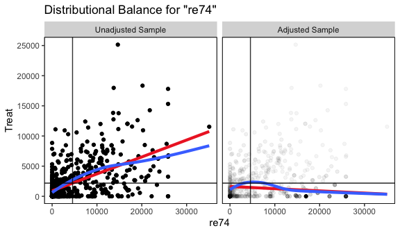

```r
#Assessing balance graphically
bal.plot(W.out.c, "re74", which = "both")
```

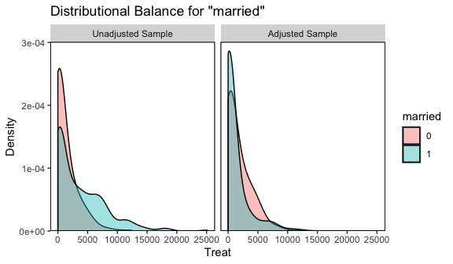

```r
bal.plot(W.out.c, "married", which = "both")
```

When balance has been achieved to a satisfactory level, users can present balance improvements in a Love plot using the `love.plot()` command, just as with binary treatments.

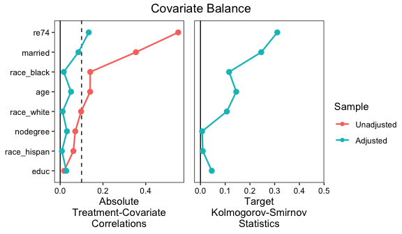

```r
#Summarizing balance in a Love plot
love.plot(W.out.c, stats = c("c", "ks"),
          thresholds = c(cor = .1),
          abs = TRUE, wrap = 20,
          limits = list(ks = c(0, .5)),
          var.order = "unadjusted", line = TRUE)
```

### Using *cobalt* with multi-category treatments

When multiple categorical treatment groups are to be compared with each other, it is possible to create balance across the treatment groups using preprocessing methods. Lopez and Gutman (2017) compare methods used to create balance with multi-category treatments and briefly describe balance assessment for these scenarios. An important note is the choice of estimand to be examined. The ATE represents the causal effect of moving from one treatment group to another for all units in the population; the ATT represents the causal effect of moving from one treatment group to another “focal” treatment group for just the units that would have been in the focal treatment group.

In *cobalt*, users can assess and present balance for multi-category treatments using `bal.tab()`, `bal.plot()`, and `love.plot()`, just as with binary treatments. The output is slightly different, though, and is similar to the output generated when using these functions with clusters. `bal.tab()` computes balance statistics for all pairwise comparisons between treatment groups and a table containing the worst balance for each covariate across pairwise comparisons. For mean differences, this is described in Lopez and Gutman (2017) as “Max2SB,” or the maximum pairwise standardized bias. In *cobalt*, this has been extended to variance ratios and KS statistics as well. If the worst imbalance is not too great, then imbalance for all pairwise comparisons will not be too great either. When the ATT is desired, a focal group must be specified (unless done so automatically for some methods), and only the treatment group comparisons that involve that focal group will be computed and displayed by default.

`love.plot()` allows for the display of each pairwise treatment or the range of balance across treatment pairs for each covariate. `bal.plot()` displays distributional balance for the requested covariate across all treatment groups.

Below is an example of using *cobalt* with multi-category treatments. For this example, `race` will be the “treatment”; this type of analysis is not meant to be causal, but rather represents a method to examine disparities among groups accounting for covariates that might otherwise explain differences among groups. We will use *WeightIt* to generate balanced groups by estimating generalized propensity score weights using multinomial logistic regression.

```r
data("lalonde", package = "cobalt")

#Using WeightIt to generate weights with multinomial
#logistic regression
W.out.mn <- WeightIt::weightit(race ~ age + educ + married +
                                   nodegree + re74 + re75,
                               data = lalonde,
                               method = "glm")
```

First, we can examine balance numerically using `bal.tab()`. There are three possible pairwise comparisons, all of which can be requested with `which.treat = .all`. See `?bal.tab.multi` for more details.

```r
#Balance summary across treatment pairs
bal.tab(W.out.mn, un = TRUE)
```

```
##
## Balance summary across all treatment pairs
##             Type Max.Diff.Un Max.Diff.Adj
## age      Contin.      0.3065       0.0557
## educ     Contin.      0.5861       0.1140
## married   Binary      0.3430       0.0297
## nodegree  Binary      0.2187       0.0546
## re74     Contin.      0.6196       0.1527
## re75     Contin.      0.3442       0.1491
## Effective sample sizes
##             black hispan  white
## Unadjusted 243.    72.   299.
## Adjusted   138.38  54.99 259.59
```

```r
#Assessing balance for each pair of treatments
bal.tab(W.out.mn, un = TRUE,
        disp = "means",
        which.treat = .all)
```

```
## Balance by treatment pair
##
## ─── black (0) vs. hispan (1) ────────────────────────────────────────────
##
## Balance Measures
##             Type    M.0.Un    M.1.Un Diff.Un   M.0.Adj   M.1.Adj Diff.Adj
## age      Contin.   26.0123   25.9167 -0.0101   26.6155   27.0006   0.0408
## educ     Contin.   10.2346    9.0139 -0.4515   10.5033   10.1950  -0.1140
## married   Binary    0.2222    0.4444  0.2222    0.4109    0.3840  -0.0269
## nodegree  Binary    0.6955    0.7639  0.0684    0.6005    0.6552   0.0546
## re74     Contin. 2499.4492 4431.6260  0.3183 5486.7968 4740.5305  -0.1229
## re75     Contin. 1613.7752 2741.3920  0.3442 2665.9699 2229.2822  -0.1333
##
## Effective sample sizes
##             black hispan
## Unadjusted 243.    72.
## Adjusted   138.38  54.99
##
## ─── black (0) vs. white (1) ─────────────────────────────────────────────
##
## Balance Measures
##             Type    M.0.Un    M.1.Un Diff.Un   M.0.Adj   M.1.Adj Diff.Adj
## age      Contin.   26.0123   28.8094  0.2963   26.6155   27.1412   0.0557
## educ     Contin.   10.2346   10.5987  0.1347   10.5033   10.3204  -0.0676
## married   Binary    0.2222    0.5652  0.3430    0.4109    0.4137   0.0028
## nodegree  Binary    0.6955    0.5452 -0.1503    0.6005    0.6246   0.0240
## re74     Contin. 2499.4492 6260.5029  0.6196 5486.7968 4560.0208  -0.1527
## re75     Contin. 1613.7752 2515.1320  0.2752 2665.9699 2177.6625  -0.1491
##
## Effective sample sizes
##             black  white
## Unadjusted 243.   299.
## Adjusted   138.38 259.59
##
## ─── hispan (0) vs. white (1) ────────────────────────────────────────────
##
## Balance Measures
##             Type    M.0.Un    M.1.Un Diff.Un   M.0.Adj   M.1.Adj Diff.Adj
## age      Contin.   25.9167   28.8094  0.3065   27.0006   27.1412   0.0149
## educ     Contin.    9.0139   10.5987  0.5861   10.1950   10.3204   0.0464
## married   Binary    0.4444    0.5652  0.1208    0.3840    0.4137   0.0297
## nodegree  Binary    0.7639    0.5452 -0.2187    0.6552    0.6246  -0.0306
## re74     Contin. 4431.6260 6260.5029  0.3013 4740.5305 4560.0208  -0.0297
## re75     Contin. 2741.3920 2515.1320 -0.0691 2229.2822 2177.6625  -0.0158
##
## Effective sample sizes
##            hispan  white
## Unadjusted  72.   299.
## Adjusted    54.99 259.59
```

We can also assess balance graphically. The same guidelines apply for multi-category treatments as do for binary treatments. Ideally, covariate distributions will look similar across all treatment groups.

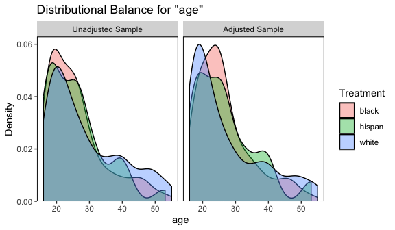

```r
#Assessing balance graphically
bal.plot(W.out.mn, "age", which = "both")
```

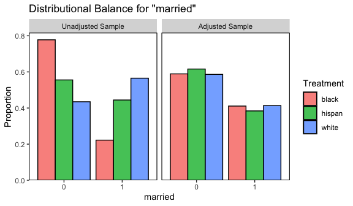

```r
bal.plot(W.out.mn, "married", which = "both")
```

Finally, we can use `love.plot()` to display balance across treatments. By default, `love.plot()` displays the values in the summary across pairwise comparisons. To request individual treatment comparisons, use `which.treat = .all` in `love.plot()`.

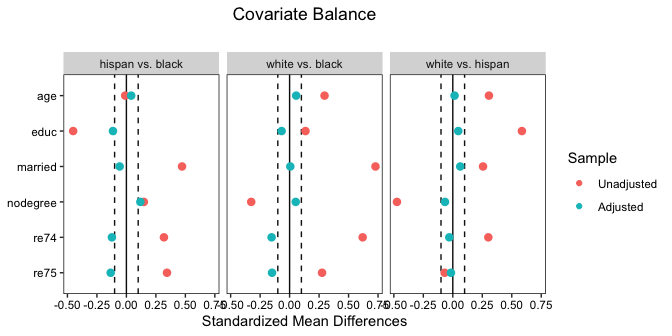

```r
#Summarizing balance in a Love plot
love.plot(W.out.mn, thresholds = c(m = .1), binary = "std",
          which.treat = .all, abs = FALSE)
```

### Using *cobalt* with censoring

When some units drop out of a study before the outcome is measured, the sample that remains may differ systematically from the sample that started, and an analysis restricted to it can be biased even if treatment was randomly assigned. Inverse probability of censoring weights (IPCW) address this by weighting the units still under observation so that they resemble the sample as a whole (Robins et al. 1995; Seaman and White 2013). Assessing whether the weights have succeeded is assessing whether, after weighting the units still under observation, they resemble the full sample they were drawn from. That full sample is the target, so it is never reweighted, and the comparison is between two overlapping samples rather than two disjoint ones.

In *cobalt*, a censoring indicator is marked with `.cens()`, which distinguishes it from a treatment wherever a treatment would ordinarily go: on the left side of a formula, or as the argument to `treat`. The indicator follows the survival convention, in which `1` means the unit was censored and `0` means it is still under observation. `bal.tab()` then compares two samples: the units with `C == 0`, carrying the censoring weights, against every unit at risk, carrying a weight of 1. Setting `un = TRUE` adds the same comparison before weighting, which is the imbalance the weights were estimated to remove. All the balance statistics available for binary treatments are available here, and the columns are named for the two samples rather than for treatment groups, so `M.Uncensored` and `M.Full` are their means and `Diff` is the difference between the full sample and the uncensored one.

To demonstrate, we add an indicator of loss to follow-up to the `lalonde` data, so that `re78` is observed only for the units with `C == 0`. Older units and those with lower 1974 earnings are more likely to drop out. As with the continuous treatment example above, this is constructed rather than real, but the workflow is the one that would be used with a genuine dropout indicator.

```r
data("lalonde", package = "cobalt")

set.seed(100)
lalonde$C <- rbinom(nrow(lalonde), 1,
                    prob = plogis(-4 + .1 * lalonde$age -
                                      .00003 * lalonde$re74))

#Estimating inverse probability of censoring weights
W.out.cens <- WeightIt::weightit(.cens(C) ~ age + educ + race + married +
                                     nodegree + re74 + re75,
                                 data = lalonde,
                                 method = "glm")
```

`bal.tab()` accepts the `weightit` object directly. Note that the sample size table has a single column, because the target sample is the same in every row, and that `Uncensored` and `Censored` sum to `Full`.

```r
#Assessing balance numerically
bal.tab(W.out.cens, un = TRUE, disp = "m")
```

```
## Balance Measures
##                 Type M.Uncensored.Un M.Full.Un Diff.Un M.Uncensored.Adj
## prop.score  Distance          0.1783    0.2052  0.1818           0.2080
## age          Contin.         25.6127   27.3632  0.1772          27.5011
## educ         Contin.         10.3525   10.2687 -0.0319          10.2788
## race_black    Binary          0.4119    0.3958 -0.0161           0.3954
## race_hispan   Binary          0.1189    0.1173 -0.0016           0.1175
## race_white    Binary          0.4693    0.4870  0.0177           0.4871
## married       Binary          0.3934    0.4153  0.0219           0.4192
## nodegree      Binary          0.6434    0.6303 -0.0131           0.6294
## re74         Contin.       4261.4050 4557.5466  0.0457        4547.8372
## re75         Contin.       2144.9218 2184.9382  0.0121        2183.8645
##             M.Full.Adj Diff.Adj
## prop.score      0.2052  -0.0186
## age            27.3632  -0.0140
## educ           10.2687  -0.0038
## race_black      0.3958   0.0004
## race_hispan     0.1173  -0.0003
## race_white      0.4870  -0.0001
## married         0.4153  -0.0039
## nodegree        0.6303   0.0009
## re74         4557.5466   0.0015
## re75         2184.9382   0.0003
##
## Effective sample sizes
##             Total
## Full       614.
## Uncensored 488.
## Adjusted   458.34
## Censored   126.
```

The units still under observation had lower values of `age` than the sample as a whole before weighting (a standardized mean difference of about .177), and the weights remove that difference. By default the standardization factor for standardized mean differences is the standard deviation in the full at-risk sample, which can be changed by setting `s.d.denom` to `"uncensored"` or to any of the values available for binary treatments.

`bal.plot()` and `love.plot()` work as they do elsewhere. `bal.plot()` displays the weighted uncensored sample against the unweighted full sample, with the two labeled as such.

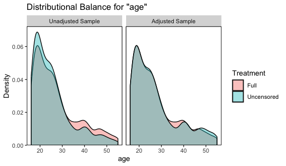

```r
#Assessing balance graphically
bal.plot(W.out.cens, "age", which = "both")
```

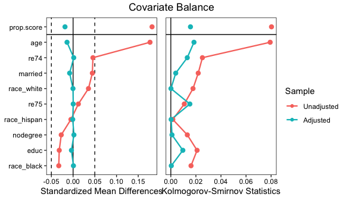

```r
#Summarizing balance in a Love plot
love.plot(W.out.cens, stats = c("m", "ks"),
          thresholds = c(m = .05), binary = "std",
          var.order = "unadjusted", line = TRUE)
```

Weights estimated outside *WeightIt* can be supplied to the formula or data frame interfaces, exactly as with a treatment:

```r
bal.tab(.cens(C) ~ age + educ + race + married + nodegree + re74 + re75,
        data = lalonde, weights = W.out.cens$weights, un = TRUE)
```

`cluster`, `imp`, and `subclass` all apply. Subclassification deserves a note of its own: it is not just compatible with censoring but is itself a way of solving a censoring problem, in that within each subclass the units still under observation should resemble every at-risk unit in it. Supplying `subclass` produces a balance table for each subclass and a summary across them, in which a unit still under observation in subclass $k$ is weighted by $n_k / n_{k1}$, the number of at-risk units in the subclass over the number of them still under observation. See `?class-bal.tab.cens` for the full set of arguments and the shape of the output, and `vignette("longitudinal-treat")` for censoring that occurs between treatment periods.

### Comparing balancing methods

It is possible to display balance for multiple balancing methods at the same time in `bal.tab()`, `bal.plot()`, and `love.plot()`. To do so, weights generated from each balancing method need to be supplied together in each call. This can be done by supplying the weights or the output objects themselves. For example, we can compare matching and inverse probability weighting for the ATT using the following code and the output generated above.

```r
bal.tab(treat ~ age + educ + married + race +
            nodegree + re74 + re75, data = lalonde,
        weights = list(Matched = m.out,
                       IPW = W.out),
        disp.v.ratio = TRUE)
```

```
## Balance Measures
##                Type Diff.Matched V.Ratio.Matched Diff.IPW V.Ratio.IPW
## age         Contin.       0.2395          0.5565   0.1112      0.5086
## educ        Contin.      -0.0161          0.5773  -0.0641      0.6018
## married      Binary       0.0595               .  -0.0938           .
## race_black   Binary       0.0054               .  -0.0044           .
## race_hispan  Binary      -0.0054               .   0.0016           .
## race_white   Binary       0.0000               .   0.0028           .
## nodegree     Binary       0.0054               .   0.1151           .
## re74        Contin.      -0.0493          1.0363  -0.0039      1.4821
## re75        Contin.       0.0087          2.1294  -0.0428      1.1712
##
## Effective sample sizes
##         Control Treated
## All      429.       185
## Matched   46.31     185
## IPW      108.2      185
```

To use `bal.plot()`, the same syntax can be used:

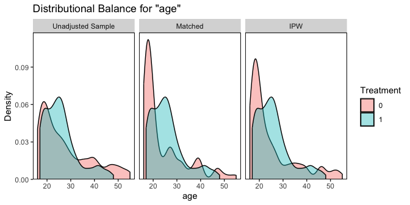

```r
bal.plot(treat ~ age, data = lalonde,
         weights = list(Matched = m.out,
                        IPW = W.out),
         var.name = "age", which = "both")
```

With `love.plot()`, `var.order` can be `"unadjusted"`, `"alphabetical"`, or one of the names of the weights to order the variables. Also, `colors` and `shapes` should have the same length as the number of weights or have length 1.

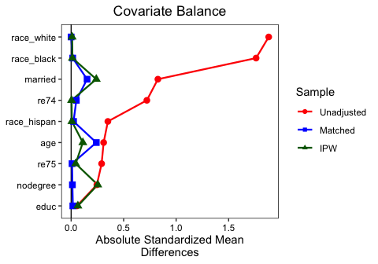

```r
love.plot(treat ~ age + educ + married + race +
              nodegree + re74 + re75,
          data = lalonde,
          weights = list(Matched = m.out,
                         IPW = W.out),
          var.order = "unadjusted", binary = "std",
          abs = TRUE, colors = c("red", "blue", "darkgreen"),
          shapes = c("circle", "square", "triangle"),
          line = TRUE)
```

Another way to compare weights from multiple objects is to call `bal.tab()` with one object as usual and supply the other(s) to the `weights` argument; see below for an example:

```r
bal.tab(m.out, weights = list(IPW = W.out))
```

### Using the prognostic score for balance assessment

The prognostic score is the model-predicted outcome for an individual, excluding the treatment variable in the model (Hansen 2008). Stuart et al. (2013) found that prognostic scores can be an extremely effective tool for assessing balance, greatly outperforming mean differences on covariates and significance tests. This is true even if the prognostic score model is slightly misspecified. Although the use of prognostic scores appears to violate the spirit of preprocessing in that users observe the outcome variable prior to treatment effect estimation, typically the prognostic score model is estimated in just the control group, so that the outcome of the treated group (which may contain treatment effect information) is excluded from analysis.

Assessing balance on the prognostic score is simple in *cobalt*, and highly recommended when available. The steps are:

1. Estimate the outcome model in the control group
2. Generate model-predicted outcome values for both the treated and control groups
3. Assess balance on prognostic scores by comparing standardized mean differences

To use prognostic scores in *cobalt*, simply add the prognostic score as a variable in the argument to `distance`. Below is an example of how to do so after a call to `matchit()`:

```r
ctrl.fit <- glm(re78 ~ age + educ + race +
                    married + nodegree + re74 + re75,
                data = lalonde,
                subset = treat == 0)
lalonde$prog.score <- predict(ctrl.fit, newdata = lalonde)

bal.tab(m.out, stats = c("m", "ks"),
        distance = lalonde["prog.score"])
```

```
## Balance Measures
##                 Type Diff.Adj KS.Adj
## prog.score  Distance  -0.0485 0.1351
## distance    Distance   0.0044 0.0486
## age          Contin.   0.2395 0.3405
## educ         Contin.  -0.0161 0.0595
## married       Binary   0.0595 0.0595
## race_black    Binary   0.0054 0.0054
## race_hispan   Binary  -0.0054 0.0054
## race_white    Binary   0.0000 0.0000
## nodegree      Binary   0.0054 0.0054
## re74         Contin.  -0.0493 0.2162
## re75         Contin.   0.0087 0.2378
##
## Sample sizes
##                      Control Treated
## All                   429.       185
## Matched (ESS)          46.31     185
## Matched (Unweighted)   82.       185
## Unmatched             347.         0
```

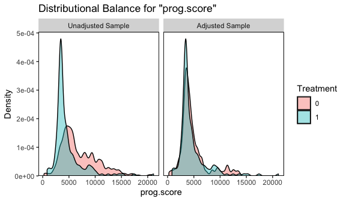

```r
bal.plot(m.out, "prog.score",
         distance = lalonde["prog.score"],
         which = "both")
```

Although the prognostic score is sensitive to the outcome estimation model used, a defensible prognostic score model can yield valid prognostic scores, which can then be used in balance assessment. In the above example, balance on the estimated prognostic score was good, so we can have some confidence that the effect estimate will be relatively unbiased, even though the `age` variable remains imbalanced. The logic is that that age is not a highly prognostic variable, which could be demonstrated by examining the standardized regression output of prognostic score model, so even though imbalance remains, such imbalance is unlikely to affect the effect estimate. The variables `re74` and `re75`, though, which are highly prognostic of the outcome, are quite balanced, thereby supporting an unbiased treatment effect estimate.

## Details on Calculations

There are calculations in *cobalt* that may be opaque to users; this section explains them. For even more details, see `vignette("faq")`.

### Variance in Standardized Mean Differences and Correlations

When computing a standardized mean difference, the raw mean difference is divided by a standard deviation, yielding a d-type effect size statistic. In `bal.tab()`, the user can control whether the standard deviation is that of the treated group or control group or a pooled estimate, calculated as the square root of the average of the group variances. In most applications, the standard deviation corresponding to the default for the method is the most appropriate.

A key detail is that the standard deviation, no matter how it is computed, is always computed using the *unadjusted* sample[^3]. This is line with how *MatchIt* computes standardized mean differences[^4], and is recommended by Stuart (2008, 2010). One reason to favor the use of the standard deviation of the unadjusted sample is that it prevents the [paradoxical situation](https://stats.stackexchange.com/a/565705/116195) that occurs when adjustment decreases both the mean difference and the spread of the sample, yielding a larger standardized mean difference than that prior to adjustment, even though the adjusted groups are now more similar. By using the same standard deviation before and after adjusting, the change in balance is isolated to the change in mean difference, rather than being conflated with an accompanying change in spread.

The same logic applies to computing the standard deviations that appear in the denominator of the treatment-covariate correlations that are used to assess balance with continuous treatments. Given that the covariance is the relevant quality to be assessed and the correlation is just a standardization used to simplify interpretation, the standardization factor should remain the same before and after adjustment. Thus, the standard deviations of the *unadjusted* sample are used in the denominator of the treatment-covariate correlation, even when the correlation in question is for the adjusted sample.

Note that when sampling weights are used, values for the unadjusted sample will be computed incorporating the sampling weights; in that sense, they are “adjusted” by the sampling weights.

### Weighted Variance

When using weighting or matching, summary values after adjustment are calculated by using weights generated from the matching or weighting process. For example, group means are computed using the standard formula for a weighted mean, incorporating the weighting or matching weights into the calculation. To estimate a weighted sample variance for use in variance ratios, sample standard deviations, or other statistics in the presence of sampling weights, there are two formulas that have been proposed:

1. $\frac{\sum_{i=1}^{n} w_{i}(x_{i} - \bar{x}_{w})^2}{(\sum_{i=1}^{n} w_{i}) - 1}$
2. $\frac{\sum_{i=1}^{n} w_{i}}{(\sum_{i=1}^{n} w_{i})^2 - \sum_{i=1}^{n} w^2_{i}} \sum_{i=1}^{n} w_{i}(x_{i} - \bar{x}_{w})^2$

The weights used in the first formula are often called “frequency weights”, while the weights in the second formula are often called normalized or “reliability weights”. *MatchIt*, *twang*, and *Matching* all use the first formula when calculating any weighted variance (*CBPS* does not compute a weighted variance). However, Austin (2008b) and Austin and Stuart (2015) recommend the second formula when considering matching weights for k:1 matching or weights for propensity score weighting. In *cobalt*, as of version 2.0.0, the second formula is used to remain in line with recommended practice. For some applications (e.g., when all weights are either 0 or 1, as in 1:1 matching), the two formulas yield the same variance estimate. In other cases, the estimates are nearly the same. For binary variables, the weighted variance is computed as $\bar{x}_{w}(1-\bar{x}_{w})$ where $\bar{x}_{w}$ is the weighted proportion of 1s in the sample.

### Effective Sample Size for Weighting

Knowledge of the sample size after adjustment is important not just for outcome analysis but also for assessing the adequacy of a conditioning specification. For example, pruning many units through common support cutoffs, caliper matching, or matching with replacement can yield very small sample sizes that hurt both the precision of the outcome estimate and the external validity of the conclusion. In both matching and weighting, the adjusted sample size is not so straightforward because the purpose of weighting is to down- and up-weight observations to create two similar samples. The “effective sample size” (ESS) is a measure of the sample size a non-weighted sample would have to have to achieve the same level of precision as the weighted sample (Ridgeway 2006). This measure is implemented in *twang* using the following formula:
$$ESS = \frac{(\sum_{i=1}^{n}
w_{i})^2}{\sum_{i=1}^{n} w_{i}^2}$$
Shook-Sa and Hudgens (2020) derived the specific relationship between the ESS and the standard error of a propensity score-weighted mean.

## What’s Missing in *cobalt*

A fair amount is missing in *cobalt* that is present in other packages. Though there is value in many of the aspects that *cobalt* lacks, many were purposefully excluded based on methodological recommendations that conflict with the current use of some other packages. Below are aspects that are intentionally missing from *cobalt* that users may be used to from other packages. Their reasons for exclusion are included, with the hope that users of *cobalt* will be satisfied with what is available and be confident they are using the most methodologically sound tools for balance assessment.

### Test Statistics and P-values

Some of the early literature on propensity score matching included measures for balance assessment that relied on hypothesis tests for the independence of treatment assignment and covariates after adjustment (e.g., Hansen 2004; Rosenbaum and Rubin 1985). In a review of propensity score applications in the social sciences, Thoemmes and Kim (2011) found that over 66% of studies used significance tests to assess balance. Likewise, Austin (2008a) found that over 70% of studies using propensity scores in the medical literature used significance tests to assess balance, a finding replicated by Ali et al. (2015). These hypothesis tests can come in many forms: t-tests for the difference in means between groups, chi-square tests for the difference in proportion between groups, Kolmogorov-Smirnov tests for the difference in cumulative density between groups, or F-tests for the difference in means between groups across subclasses.

The use of hypothesis tests appears natural here: if balance is achieved, we would not expect extreme values for the test statistics, and we can quantify the probability of observing imbalance as extreme as the one observed if no imbalance is present as a way to assess whether there is balance, as we can do with standard hypothesis testing. But this view is not shared by the methodological community: many contemporary propensity score methodologists recommend against using hypothesis tests for balance assessment (e.g., Ho et al. 2007; Imai et al. 2008; Austin 2011, 2009; Stuart 2010; Thoemmes and Kim 2011; Ali et al. 2015). There are logical reasons for this preference against hypothesis tests, noted clearly in Ali et al. (2015) and Linden (2014): they are influenced by sample size, which fluctuates during adjustment, and the theory behind them is inappropriate because balance is a quality solely of the sample in question, not in relation to a population. The relevant information in a hypothesis test for group differences is the standardized magnitude of the group difference, and so such a measure is preferred.

Because hypothesis tests can be misleading and their use is discouraged by leading methodologists, they have been completely excluded in *cobalt* in favor of summary statistics. This stands in contrast to *twang*, *Matching*, and *RItools*, all of which report hypothesis test p-values in their balance output.

### Q-Q Plots and Summaries

Q-Q plots have been recommended as tools to assess distributional balance of covariates between groups (Ho et al. 2007), and are implemented in *MatchIt* and *Matching* (*twang* implements them but for a different purpose). Statistics summarizing the degree of imbalance in Q-Q plots are also reported in both *MatchIt* and *Matching*. *MatchIt*’s `summary()` command reports “eQQ Mean” and “eQQ Max” for each covariate before and after adjustment. These are the mean and maximum distance between the treated and control group empirical Q-Q plots on the scale of the covariate. Values close to 0 indicate good balance between groups for the given covariate.

A weakness of empirical Q-Q plots is that they don’t reveal much about the differences in the shapes of the distributions between the groups, which is a key aspect of distributional balance. A density plot essentially contains the same information, but is clearer and more intuitive. Although the assessment of balance using an empirical Q-Q plot is straightforward (i.e., deviations from the 45-degree line indicate imbalances), density plots present the information in a way more in line with the actual goals of conditioning, in particular, that the distributions of treated and control units are similar (Ho et al. 2007). Empirical Q-Q plot summary statistics may be useful in quantifying imbalance, but currently there are few recommendations for their use.

## What’s Added in *cobalt*

There are several features in *cobalt* that are present in few, if any, balance assessment tools in the major packages. These come from methodological recommendations and requests by members of the methodological community.

### Density Plots

As mentioned above, *cobalt* displays density plots and bar charts rather than empirical Q-Q plots for the assessment of distributional similarity. These charts are not standard in any of the conditioning packages, but can be an intuitive and helpful tool for deciding whether adjustment has yielded similar distributions between the groups for given covariates. Though there are no obvious heuristics for deciding how much dissimilarity is too much dissimilarity, density plots do avoid the sometimes confusing logic of empirical Q-Q plots in favor of simplicity and interpretability. Austin (2009) and Linden (2014) consider density plots as a compliment to empirical Q-Q plots to more finely examine balance after adjusting.

### Variance Ratios

Although mean differences (including t-tests and chi-square tests) are the most reported balance statistic (Thoemmes and Kim 2011), variance ratios have been recommended in the literature as a means to further examine balance between groups (Austin 2009; Ho et al. 2007; Imai et al. 2008). When group variances are similar, the variance ratio will be close to 1. Common thresholds for the variance ratio for balanced groups are .5 and 2 (Stuart 2010; Rubin 2001), though ratios closer to 1 are preferred. Although `bal.tab()` in *cobalt* does not display variance ratios by default, they can be easily requested and have thresholds set.

### Distinguishing Continuous and Binary Covariates

Continuous and binary covariates are treated differently by default in `bal.tab()` and `bal.plot()`. For continuous covariates, the standard summaries apply: standardized mean differences, variance ratios, and density plots. For binary covariates, raw differences in proportion and bar charts are preferable, and variance ratios are useless.

The value of standardized mean differences for continuous variables is that they are on the same scale so that they can be compared across variables, and they allow for a simple interpretation even when the details of the variable’s original scale are unclear to the analyst. None of these advantages are passed to binary variables because binary variables are already on the same scale (i.e., a proportion), and the scale is easily interpretable. In addition, the details of standardizing the proportion difference of a binary variable involve dividing the proportion difference by a variance, but the variance of a binary variable is a function of its proportion (Austin 2009). Standardizing the proportion difference of a binary variable can yield the following counterintuitive result: if $X_{T} = .2$ and $X_{C} = .3$, the standardized difference in proportion would be different from that if $X_{T} = .5$ and $X_{C} = .6$, even though the expectation is that the balance statistic should be the same for both scenarios because both would yield the same degree of bias in the effect estimate. In addition, Ali et al. (2014) found that the raw difference in proportion was a better predictor of bias than the standardized mean difference for binary variables[^5].

*MatchIt* allows users to view either standardized mean differences for all covariates or raw differences for all covariates, and *twang* and *Matching* display standardized differences for all variables but calculate test statistics depending on whether the covariate is continuous or binary (*CBPS* does not calculate mean differences, but presents both standardized and unstandardized means for all covariates). *cobalt* allows the user to select how the differences are to be calculated separately for continuous and binary variables, and uses the intuitive default that mean differences for continuous variables should be standardized while proportion differences for binary variables should not be.

Because the variance of a binary variable is a function only of its proportion, the variance ratio of a binary variable in two groups is a function only of their proportions, thereby containing no more information than the simple difference in proportion. Therefore, for binary variables, *cobalt* does not compute variance ratios, as they can be misleading.

### Interactions and Polynomials

Because the goal of a balancing procedure is to achieve independence between treatment and the joint distribution of covariates, evaluating univariate distributional similarity may not be sufficient for assessing balance completely. Some writers have recommended the evaluation of distributional similarity of interaction and polynomial terms to account for this. Rather than requiring the user to create interaction variables by hand, `bal.tab()` can produce balance statistics for interactions by specifying `int = TRUE`, similar to *MatchIt*’s `summary()`, and polynomials by specifying a numeric argument to `poly` (e.g., 2 for squared terms).

When including categorical variables in balance assessment, `bal.tab()` makes a few adjustments under the hood that deserve explanation. First, if a variable is binary and is entered as a factor variable, balance statistics will only be displayed for one level of the variable (since the other is redundant), but balance on interaction terms will be displayed for all values of the variables.

For example, consider a binary variable “Sex” with values “Male” and “Female”. Many functions, including `bal.tab()`, `lm()`, and `matchit()`, will split this variable into two numeric dummy variables, “Male” and “Female”, each of which take on the values 0 and 1. One of these new variables is completely redundant: all of the relevant information is stored in just “Female”, so “Male” can be eliminated. Consider now a variable “Age”: what is desired in balance assessment is the interaction between Age and Sex; distributional similarity on the interaction between the treated and untreated groups is evidence of multivariate balance. Computing the interaction between “Female” and “Age” yields a variable that is “Age” when the unit is female and 0 otherwise. The average value of this variable is the average age of females in the sample, weighted by the proportion of females. If the two treatment groups have similar average values of this variable, this is taken as evidence for balance on the interaction between sex and age, though it is entirely possible that the average age of men differs greatly between the two groups. Thus, an additional variable computed as the product of “Male” and “Age” would be necessary to fully assess balance on the interaction between sex and age. `bal.tab()` produces this interaction term, which would otherwise be unobserved by the analyst[^6]. The interactions among levels of a single factor, which always be equal to 0, are excluded in `bal.tab()`.

Interactions between the distance measure and other variables have been excluded in `bal.tab()`, noting that balance on the distance measure is neither necessary nor sufficient for covariate balance.

Because the number of computations increases both with sample size and number of variables, computing interactions can be slow. In addition to taking the product of variables two at a time, `bal.tab()` checks variables to ensure no variables were created that contain only a single value (e.g., interactions between mutually exclusive covariates) or are redundant with respect to other variables (e.g., manually created interactions or manually split factors). This results in cleaner, more useful output, but also requires more computing time. It is advisable to store the results of a call to `bal.tab()` to a variable to be accessed later rather than to call `bal.tab()` several times when using it with interactions.

### Clusters

The use of preprocessing techniques in the context of multilevel data (e.g., students within schools, patients within hospitals) has been increasing. Currently no other package allows for any balance assessment with respect to clusters, except by manually examining balance on clusters specified manually. It can be useful to examine balance within each cluster, but, especially if there are many clusters, it may also be useful to examine a summary of balance across clusters. In all of its functions, *cobalt* provides options for displaying balance on clustered data sets. This can occur either within specified clusters or across all clusters. Details on using *cobalt* with clustered data can be found in `vignette("segmented-data")`.

### Missing Data

Missing data is frequent in all research involving human subjects, and especially in the large survey data sets that are often used to answer causal questions in the social sciences. *cobalt* functions can assess balance not only on the observed covariates but also on the proportion of missing values for each covariate. Additionally, *cobalt* has features designed especially for assessing balance on preprocessed data sets that have been multiply imputed to address covariate missingness. Although the guidelines on assessing balance on multiply imputed data sets are scarce, it is valuable to assess balance within and across imputed data sets to ensure the preprocessing solution is applicable to all imputations. Details on using *cobalt* with multiply imputed data can be found in `vignette("segmented-data")`.

## For Programmers: Integrating *cobalt* with Your Package

If you are designing a new R package for preprocessing that performs similar functions to *MatchIt*, *twang*, *Matching*, *optmatch*, *CBPS*, *ebal*, *designmatch*, *cem*, or *WeightIt*, you might consider integrating *cobalt* into your package to avoid programming your own balance assessment tool. The simplest way to do so is to have the output of your preprocessing function contain sufficient elements for use with the default method for `bal.tab()` and `bal.plot()`. See `?bal.tab.default` for more information on how this might work.

As *cobalt* is updated to remain in line with methodological recommendations, the balance assessment capabilities for your function’s output will also improve if *cobalt* is a balance assessment tool for your package. In this way, users of your package can use the most up-to-date balance assessment tools programmed in *cobalt* without you having to update your package.

If you develop a new balance assessment tool, this may also be able to be integrated into *cobalt*, especially if it would be applicable to balance assessment generally in matching, weighting, or subclassification. Incorporating a new tool into *cobalt* may be a good way to broaden its use.

*cobalt* includes a small suite of functions that compute balance statistics on matrices of covariates with and without weights. These include `col_w_smd()` for computing (standardized) mean differences, `col_w_vr()` for computing variance ratios, `col_w_ks()` for computing KS statistics, `col_w_ovl()` for computing the complement of the overlapping statistics (Franklin et al. 2014), and `col_w_corr()` for computing treatment-covariate correlations. These all run fairly quickly but are still quite flexible, so they can be used to quickly and simply compute balance statistics in other packages. They are used internally in `bal.tab()`, and they might be able to be used internally in other functions (e.g., to choose a tuning parameter based on a measure of balance). See `help("balance-summary")` for details.

The functions `bal.init()` and `bal.compute()` can be used to compute scalar balance statistics efficiently, which can be useful in tuning a parameter to achieve balance or quickly summarizing balance across many specifications. See `vignette("optimizing-balance")` for more information on how and when to use these functions.

## Acknowledgments

I thank Kirsten Kainz and Elizabeth Stuart for their support and advice on *cobalt*’s creation. I thank Zachary Fisher and Brian Barkley for their advice on developing an R package.

## References

Ali, M. Sanni, Rolf H. H. Groenwold, Svetlana V. Belitser, et al. 2015. “Reporting of Covariate Selection and Balance Assessment in Propensity Score Analysis Is Suboptimal: A Systematic Review.” *Journal of Clinical Epidemiology* 68 (2): 122–31. https://doi.org/10.1016/j.jclinepi.2014.08.011.

Ali, M. Sanni, Rolf H. H. Groenwold, Wiebe R. Pestman, et al. 2014. “Propensity Score Balance Measures in Pharmacoepidemiology: A Simulation Study.” *Pharmacoepidemiology and Drug Safety* 23 (8): 802–11. https://doi.org/10.1002/pds.3574.

Austin, Peter C. 2008a. “A Critical Appraisal of Propensity-Score Matching in the Medical Literature Between 1996 and 2003.” *Statistics in Medicine* 27 (12): 2037–49. https://doi.org/10.1002/sim.3150.

Austin, Peter C. 2008b. “Assessing Balance in Measured Baseline Covariates When Using Many-to-One Matching on the Propensity-Score.” *Pharmacoepidemiology and Drug Safety* 17 (12): 1218–25. https://doi.org/10.1002/pds.1674.

Austin, Peter C. 2009. “Balance Diagnostics for Comparing the Distribution of Baseline Covariates Between Treatment Groups in Propensity-Score Matched Samples.” *Statistics in Medicine* 28 (25): 3083–107. https://doi.org/10.1002/sim.3697.

Austin, Peter C. 2011. “An Introduction to Propensity Score Methods for Reducing the Effects of Confounding in Observational Studies.” *Multivariate Behavioral Research* 46 (3): 399–424. https://doi.org/10.1080/00273171.2011.568786.

Austin, Peter C. 2019. “Assessing Covariate Balance When Using the Generalized Propensity Score with Quantitative or Continuous Exposures.” *Statistical Methods in Medical Research* 28 (5): 1365–77. https://doi.org/10.1177/0962280218756159.

Austin, Peter C., and Elizabeth A. Stuart. 2015. “Moving Towards Best Practice When Using Inverse Probability of Treatment Weighting (IPTW) Using the Propensity Score to Estimate Causal Treatment Effects in Observational Studies.” *Statistics in Medicine* 34 (28): 3661–79. https://doi.org/10.1002/sim.6607.

Belitser, Svetlana V., Edwin P. Martens, Wiebe R. Pestman, Rolf H. H. Groenwold, Anthonius de Boer, and Olaf H. Klungel. 2011. “Measuring Balance and Model Selection in Propensity Score Methods.” *Pharmacoepidemiology and Drug Safety* 20 (11): 1115–29. https://doi.org/10.1002/pds.2188.

Bia, Michela, and Alessandra Mattei. 2008. “A Stata Package for the Estimation of the Dose-Response Function Through Adjustment for the Generalized Propensity Score.” *The Stata Journal: Promoting Communications on Statistics and Stata* 8 (3): 354–73. https://doi.org/10.1177/1536867X0800800303.

Fong, Christian, Chad Hazlett, and Kosuke Imai. 2018. “Covariate Balancing Propensity Score for a Continuous Treatment: Application to the Efficacy of Political Advertisements.” *The Annals of Applied Statistics* 12 (1): 156–77. https://doi.org/10.1214/17-AOAS1101.

Fong, Christian, Marc Ratkovic, Chad Hazlett, Xiaolin Yang, and Kosuke Imai. 2019. *CBPS: Covariate Balancing Propensity Score*. Released.

Franklin, Jessica M., Jeremy A. Rassen, Diana Ackermann, Dorothee B. Bartels, and Sebastian Schneeweiss. 2014. “Metrics for Covariate Balance in Cohort Studies of Causal Effects.” *Statistics in Medicine* 33 (10): 1685–99. https://doi.org/10.1002/sim.6058.

Greifer, Noah. 2021. *WeightIt: Weighting for Covariate Balance in Observational Studies*.

Greifer, Noah, and Elizabeth A Stuart. 2021. “Matching Methods for Confounder Adjustment: An Addition to the Epidemiologist’s Toolbox.” *Epidemiologic Reviews* 43 (1): 118–29. https://doi.org/10.1093/epirev/mxab003.

Hainmueller, Jens. 2014. *Ebal: Entropy Reweighting to Create Balanced Samples*.

Hansen, Ben B. 2004. “Full Matching in an Observational Study of Coaching for the SAT.” *Journal of the American Statistical Association* 99 (467): 609–18. https://doi.org/10.1198/016214504000000647.

Hansen, Ben B. 2008. “The Prognostic Analogue of the Propensity Score.” *Biometrika* 95 (2): 481–88. https://doi.org/10.1093/biomet/asn004.

Hansen, Ben B, and Stephanie Olsen Klopfer. 2006. “Optimal Full Matching and Related Designs via Network Flows.” *Journal of Computational and Graphical Statistics* 15 (3): 609–27. https://doi.org/10.1198/106186006X137047.

Hirano, Keisuke, and Guido W. Imbens. 2005. “The Propensity Score with Continuous Treatments.” In *Wiley Series in Probability and Statistics*, edited by Andrew Gelman and Xiao-Li Meng. John Wiley & Sons, Ltd. https://doi.org/10.1002/0470090456.ch7.

Ho, Daniel E., Kosuke Imai, Gary King, and Elizabeth A. Stuart. 2007. “Matching as Nonparametric Preprocessing for Reducing Model Dependence in Parametric Causal Inference.” *Political Analysis* 15 (3): 199–236. https://doi.org/10.1093/pan/mpl013.

Ho, Daniel E., Kosuke Imai, Gary King, and Elizabeth A. Stuart. 2011. “MatchIt: Nonparametric Preprocessing for Parametric Causal Inference.” *Journal of Statistical Software, Articles* 42 (8): 1–28. https://doi.org/10.18637/jss.v042.i08.

Iacus, Stefano, Gary King, and Giuseppe Porro. 2009. “Cem: Software for Coarsened Exact Matching.” *Journal of Statistical Software* 30 (1): 1–27. https://doi.org/10.18637/jss.v030.i09.

Imai, Kosuke, Gary King, and Elizabeth A. Stuart. 2008. “Misunderstandings Between Experimentalists and Observationalists about Causal Inference.” *Journal of the Royal Statistical Society. Series A (Statistics in Society)* 171 (2): 481–502. https://doi.org/10.1111/j.1467-985X.2007.00527.x.

Keller, B., and E. Tipton. 2016. “Propensity Score Analysis in R: A Software Review.” *Journal of Educational and Behavioral Statistics* 41 (3): 326–48. https://doi.org/10.3102/1076998616631744.

King, Gary, and Richard Nielsen. 2019. “Why Propensity Scores Should Not Be Used for Matching.” *Political Analysis*, May, 1–20. https://doi.org/10.1017/pan.2019.11.

Linden, Ariel. 2014. “Combining Propensity Score-Based Stratification and Weighting to Improve Causal Inference in the Evaluation of Health Care Interventions.” *Journal of Evaluation in Clinical Practice* 20 (6): 1065–71. https://doi.org/10.1111/jep.12254.

Lopez, Michael J., and Roee Gutman. 2017. “Estimation of Causal Effects with Multiple Treatments: A Review and New Ideas.” *Statistical Science* 32 (3): 432–54. https://doi.org/10.1214/17-STS612.

Pishgar, Farhad, Noah Greifer, Clémence Leyrat, and Elizabeth Stuart. 2021. “MatchThem:: Matching and Weighting After Multiple Imputation.” *The R Journal*.

Ridgeway, Greg. 2006. “Assessing the Effect of Race Bias in Post-Traffic Stop Outcomes Using Propensity Scores.” *Journal of Quantitative Criminology* 22 (1): 1–29. https://doi.org/10.1007/s10940-005-9000-9.

Ridgeway, Greg, Daniel F. McCaffrey, Andrew Morral, Lane Burgette, and Beth Ann Griffin. 2016. “Toolkit for Weighting and Analysis of Nonequivalent Groups: A Tutorial for the Twang Package.” *R Vignette. RAND*.

Robins, James M., Andrea Rotnitzky, and Lue Ping Zhao. 1995. “Analysis of Semiparametric Regression Models for Repeated Outcomes in the Presence of Missing Data.” *Journal of the American Statistical Association* 90 (429): 106–21. https://doi.org/10.1080/01621459.1995.10476493.

Rosenbaum, Paul R., and Donald B. Rubin. 1985. “Constructing a Control Group Using Multivariate Matched Sampling Methods That Incorporate the Propensity Score.” *The American Statistician* 39 (1): 33–38. https://doi.org/10.2307/2683903.

Rubin, Donald B. 2001. “Using Propensity Scores to Help Design Observational Studies: Application to the Tobacco Litigation.” *Health Services and Outcomes Research Methodology* 2 (3-4): 169–88. https://doi.org/10.1023/A:1020363010465.

Seaman, Shaun R., and Ian R. White. 2013. “Review of Inverse Probability Weighting for Dealing with Missing Data.” *Statistical Methods in Medical Research* 22 (3): 278–95. https://doi.org/10.1177/0962280210395740.

Sekhon, Jasjeet S. 2011. “Multivariate and Propensity Score Matching Software with Automated Balance Optimization: The Matching Package for R.” *Journal of Statistical Software* 42 (1): 1–52. https://doi.org/10.18637/jss.v042.i07.

Shook-Sa, Bonnie E., and Michael G. Hudgens. 2020. “Power and Sample Size for Observational Studies of Point Exposure Effects.” *Biometrics*, December, biom.13405. https://doi.org/10.1111/biom.13405.

Stuart, Elizabeth A. 2008. “Developing Practical Recommendations for the Use of Propensity Scores: Discussion of ‘A Critical Appraisal of Propensity Score Matching in the Medical Literature Between 1996 and 2003’ by Peter Austin, Statistics in Medicine.” *Statistics in Medicine* 27 (12): 2062–65. https://doi.org/10.1002/sim.3207.

Stuart, Elizabeth A. 2010. “Matching Methods for Causal Inference: A Review and a Look Forward.” *Statistical Science* 25 (1): 1–21. https://doi.org/10.1214/09-STS313.

Stuart, Elizabeth A., Brian K. Lee, and Finbarr P. Leacy. 2013. “Prognostic Score-Based Balance Measures Can Be a Useful Diagnostic for Propensity Score Methods in Comparative Effectiveness Research.” *Journal of Clinical Epidemiology* 66 (8): S84. https://doi.org/10.1016/j.jclinepi.2013.01.013.

Thoemmes, Felix J., and Eun Sook Kim. 2011. “A Systematic Review of Propensity Score Methods in the Social Sciences.” *Multivariate Behavioral Research* 46 (1): 90–118. https://doi.org/10.1080/00273171.2011.540475.

Vegetabile, Brian G., Beth Ann Griffin, Donna L. Coffman, Matthew Cefalu, Michael W. Robbins, and Daniel F. McCaffrey. 2021. “Nonparametric Estimation of Population Average Dose-Response Curves Using Entropy Balancing Weights for Continuous Exposures.” *Health Services and Outcomes Research Methodology* 21 (1): 69–110. https://doi.org/10.1007/s10742-020-00236-2.

Zhu, Yeying, Donna L. Coffman, and Debashis Ghosh. 2015. “A Boosting Algorithm for Estimating Generalized Propensity Scores with Continuous Treatments.” *Journal of Causal Inference* 3 (1). https://doi.org/10.1515/jci-2014-0022.

Zubizarreta, Jose R., Cinar Kilcioglu, and Juan P. Vielma. 2018. *Designmatch: Matched Samples That Are Balanced and Representative by Design*.

Zubizarreta, Jose R., Yige Li, and Kwangho Kim. 2021. *Sbw: Stable Balancing Weights for Causal Inference and Missing Data*. Manual.

[^1]: If none of the examples are working, this may be because *MatchIt*, *twang*, or *WeightIt* are missing. Such issues should be fixed soon.
[^2]: Older versions used the arguments `disp.means` and `disp.sds`, and these are still allowed.
[^3]: Unless common support is used in *Matching*, in which case the standard deviation is computed using the remaining unadjusted sample, or `s.d.enom` is set to `"weighted"`, which uses the standard deviation computed in the weighted (or matched) sample.
[^4]: It is important to note that both *twang* and *Matching* calculate standardized mean differences using the standard deviation of the sample in question, not the unadjusted sample, though *CBPS* uses the standard deviation of the unadjusted sample.
[^5]: Ali et al. (2014) compared the KS statistic to standardized mean differences, but the KS statistic is equivalent to the raw difference in proportion for binary variables.
[^6]: This value is a linear function of the other observed values, so it would in principle be able to be computed by the analyst, but it seems more valuable to explicitly include this “redundant calculation” for the sake of ease and completeness.